# ECON 57: Introduction to Statistics and Probability for Economists with R Programming

## Lecture 2: Introduction to R Programming - Part II

### Contents

Matrices, Frequency Tables, Data Frames, Descriptive Statistics

#### Matrices

A matrix is a two-dimensional collection of elements of the same data type. You can create matrices using the `matrix()` function on a vector. matrix() needs to be told in how many rows and columns the vector elements are to be organized. The length (number of elements) of rows must be equal, as well as the length of columns.

```r
# Create a 2x3 matrix
mat <- matrix(c(1, 2, 3, 4, 5, 6),
              nrow = 2, ncol = 3) # nrow * ncol = # of observations
print(mat)
```

```
     [,1] [,2] [,3]
[1,]    1    3    5
[2,]    2    4    6
```

```r
# Create a matrix with sales data and named dimensions
sales_matrix <- matrix(c(100, 150, 200, 80, 120, 160),
                       nrow = 2, byrow = TRUE,
                       dimnames = list(c("Month1", "Month2"),
                                        c("ProductA", "ProductB", "ProductC")))
sales_matrix
```

```r
# alternative way of setting row and column names
sales_matrix <- matrix(c(100, 150, 200, 80, 120, 160),
                       nrow = 3, byrow = TRUE)

rownames(sales_matrix) <- c("1", "2", "3")
colnames(sales_matrix) <- c("ProdA", "ProdB")
```

**Exercise 1:** Create a matrix price_matrix representing the prices of two products over the same three months. The prices are 10, 15, and 20 for Product A and 5, 8, and 12 for Product B. Then, sum the sales and price matrices to compute the total sales matrix. Hint: Use the matrix() function.

```r
price_matrix <- matrix(c(10,15,20,5,8,12),
                       ncol=2, byrow=F,
                       dimnames = list(c("1", "2", "3"),
                                       c("Product A", "Product B")))

# matrix addition
sales_matrix + price_matrix
```

**Exercise 2:** Calculate the total revenue matrix.

```r
total_revenue <- sales_matrix * price_matrix
total_revenue
```

#### Tables

A table is a special kind of matrix used for data summaries, these are similar to matrices but with some additional features for data analysis. Tables in R are represented using the data.frame class, which allows you to store data with different types (e.g., numeric, character). Let’s create a table for unemployment rates over four quarters.

```r
# Create a data frame for unemployment rates
quarters <- c("Q1", "Q2", "Q3", "Q4")
unemployment_rates <- c(5.2, 5.5, 5.7, 5.9)
unemployment_data <- data.frame(Quarter = quarters,
                                Rate = unemployment_rates)
unemployment_data
```

You can access specific elements in a matrix or table using row and column indices.

```r
# Access a specific element in the sales_matrix
sales_productA_month2 <- sales_matrix[2, "ProdA"]
sales_productA_month2
```

**Exercise 3:** Access the unemployment rate for the third quarter from the unemployment_data table.

```r
unemployment_data[3, "Rate"]
unemployment_data[, "Rate"][3]
```

#### Frequency Tables

We’ll use the table() function to create frequency tables.

```r
print(freq_table)
```

```
data
   BMW    KIA Toyota
     2      1      1
```

**Exercise 4:** Given a dataset of student grades grades = c(“A”, “B”, “B”, “C”, “A”, “A”, “B”), create a frequency table using the table() function.

```r
grades = c("A", "B", "B", "C", "A", "A", "B")
table(grades)
```

```
grades
A B C
3 3 1
```

#### Frequency Distributions

##### Univariate Numerical Frequency Distributions

Univariate numerical frequency distributions are used to summarize the distribution of a single numerical variable. There are two types: discrete and continuous.

###### Discrete Frequency Distribution

A discrete frequency distribution is used when the data consists of distinct, separate values. Let’s consider a dataset of exam scores:

```r
# Dataset of exam scores
exam_scores <- c(85, 92, 78, 90, 85, 88, 78, 92, 92, 90)

# Create a discrete frequency table
freq_table_discrete <- table(exam_scores)
print(freq_table_discrete)

# Create a histogram for the exam scores
hist(exam_scores, main = "Histogram of Exam Scores",
     xlab = "Exam Scores", ylab = "Frequency",
     col = "salmon", border = "black")
```

###### Continuous Frequency Distribution

A continuous frequency distribution is used for variables that can take any value within a range. Let’s consider a dataset of weights of randomly selected fruits in grams:

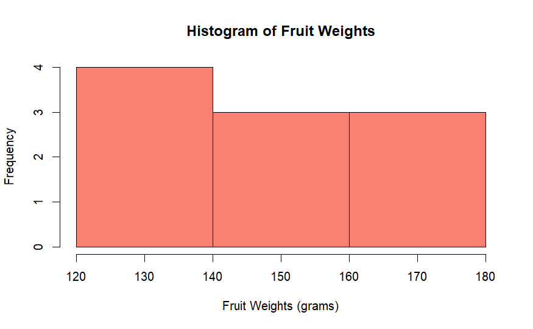

```r
# Dataset of fruit weights (in grams)
fruit_weights <- c(120, 150, 140, 170, 180, 135, 160, 150, 175, 130)

# Choose the number of bins (intervals) for the histogram
num_bins <- 4

# Create a histogram for the fruit weights
hist(fruit_weights, breaks = num_bins,
     main = "Histogram of Fruit Weights",
     xlab = "Fruit Weights (grams)", ylab = "Frequency",
     col = "salmon", border = "black")
```

```r
# Calculate class width for the continuous frequency distribution
data_range <- max(fruit_weights) - min(fruit_weights)
class_width <- data_range / num_bins
cat("Class Width:", class_width, "grams\n")
```

```
Class Width: 15 grams
```

```r
# Calculate frequency table for continuous distribution
freq_table_continuous <- cut(fruit_weights, breaks = num_bins,
                             right = TRUE, include.lowest = TRUE)
print(table(freq_table_continuous))
```

```
freq_table_continuous
[120,135] (135,150] (150,165] (165,180]
        3         3         1         3
```

```r
?cut
```

For continuous distributions, we created a histogram to visualize the distribution of fruit weights and calculated the class width to determine the bin size. We also generated a frequency table using the cut() function to categorize the data into intervals.

#### Descriptive Statistics

##### Mean and Median

The mean and median are measures of central tendency that provide insights into the typical value of a dataset. While both values indicate the center of the data, they can differ when the data is skewed or contains outliers. The median is less sensitive to outliers.

```r
# Calculate mean and median
income <- c(40000, 40000, 45000, 52000, 60000, 67000, 150000)
mean_income <- mean(income)
median_income <- median(income)

print(paste("Mean Income:", mean_income))
print(paste("Median Income:", median_income))
```

In this example, we calculated the mean and median of a dataset representing different income levels. The mean is the arithmetic average of the values, while the median is the middle value when the data is sorted. If the dataset has an even number of values, the median is the average of the two middle values.

##### Quantiles

Quantiles divide a dataset into intervals, helping us understand how values are distributed. The median is the 50th percentile, but other percentiles (e.g., quartiles) can also be calculated.

```r
# Calculate quartiles
quartiles <- quantile(income, probs = c(0.25, 0.5, 0.75))
print(paste("Income Quartiles:", quartiles)) # note vectorization
```

##### Mode

The mode is the value that appears most frequently in a dataset.

```r
# Calculate mode
income_mode <- as.numeric(names(sort(table(income), decreasing = TRUE)[1]))
print(paste("Income mode:", income_mode))
```

#### Measures of dispersion

These measures provide insights into the variability of data points.

##### Variability or Dispersion

Variability refers to how spread out the data values are. A larger variability indicates greater differences among the values.

```r
# Calculate range
data_range <- max(income) - min(income)
data_range
```

##### Indices of Dispersion

Indices of dispersion, such as variance and standard deviation, quantify the spread of data points around the mean.

```r
# Calculate variance and standard deviation
var_income <- var(income, na.rm=T)
sd_income <- sd(income, na.rm=T)

print(paste("Income variance:", var_income))
print(paste("Income standard deviation:", sd_income))
```

```r
income <- c(income, NA)

var(income, na.rm=T)
```

##### Coefficient of Variation

The coefficient of variation (CV) compares the standard deviation to the mean, providing a relative measure of variability.

```r
# Calculate coefficient of variation
cv_income <- (sd_income / mean_income) * 100
print(paste("Income CV:", cv_income))
```

##### Skewness and Kurtosis

Skewness measures the asymmetry of the distribution, while kurtosis indicates the degree of peakedness or flatness compared to a normal distribution.

```r
#install.packages("e1071")
library(e1071)  # Make sure e1071 package is installed
```

```r
# Calculate skewness and kurtosis
skewness_income <- skewness(income, na.rm = T)
kurtosis_income <- kurtosis(income, na.rm=T)

print(paste("Income skewness:", skewness_income))
print(paste("Income kurtosis", kurtosis_income))
```

**Exercise 5:** Calculate the quartiles, mode, range, variance, and other measures for a different dataset. Analyze how these measures provide insights into the characteristics of the data. How does the mean and median of your data distribution change as the standard deviation changes?

```r
# Create a dataset with a normal distribution
set.seed(123)  # Setting seed for reproducibility
data <- rnorm(1000, mean = 50, sd = 10)  # Mean = 50, Standard Deviation = 10

# Calculate quartiles
q1 <- quantile(data, 0.25)
q3 <- quantile(data, 0.75)

# Calculate mode
mode <- as.numeric(names(sort(table(data), decreasing = TRUE)[1]))

# Calculate range
range_data <- range(data)

# Calculate variance
variance <- var(data)

# Calculate mean and median for different standard deviations
std_dev_values <- c(5, 10, 15, 50, 100)

result <- data.frame(StandardDeviation = std_dev_values)

result["Mean"] <- sapply(std_dev_values, function(sd_value) {
  data <- rnorm(1000, mean = 50, sd = sd_value)
  return(mean(data))
})
result$Median <- sapply(std_dev_values, function(sd_value) {
  data <- rnorm(1000, mean = 50, sd = sd_value)
  return(median(data))
})

# Display the results
cat("Quartile 1:", q1, "\n")
cat("Quartile 3:", q3, "\n")
cat("Mode:", mode, "\n")
cat("Range:", range_data, "\n")
cat("Variance:", variance, "\n")
cat("Mean and Median for Different Standard Deviations:\n")
print(result)
```